# Credit Default Scorecard

**Building a credit risk scorecard the way a lender actually builds one.**

The goal is not to maximise a leaderboard metric. It is to produce a model a credit committee can approve: one where every point of the score can be explained to a declined applicant, where the cut-off is chosen against the real cost of being wrong, and where no protected attribute enters the decision.

**Data:** [Statlog (German Credit)](https://archive.ics.uci.edu/dataset/144/statlog+german+credit+data), UC Irvine Machine Learning Repository — 1,000 real loan applications, 20 attributes, labelled good or bad.

The dataset ships with a cost matrix, and it is asymmetric: **lending to a bad applicant costs five times as much as declining a good one.** Almost every published analysis of this data ignores that and reports accuracy. Accuracy is the wrong metric when the two errors cost different amounts, and this notebook uses the documented 5:1 ratio to pick the cut-off instead.

### Approach

| Step | Why |
| --- | --- |
| Drop protected attributes | Sex and foreign-worker status are unlawful inputs to a lending decision |
| Weight of Evidence binning | Makes every feature monotonic in log-odds and handles non-linearity without losing interpretability |
| Information Value screening | Standard scorecard feature selection |
| Logistic regression on WOE | The regulator-friendly model; coefficients convert directly into points |
| Gradient boosting benchmark | To measure what interpretability actually costs in AUC |
| KS, gains, calibration | How a risk team reads a model, rather than accuracy |
| Cost-based cut-off | Uses the documented 5:1 matrix |

```python
import numpy as np, pandas as pd, matplotlib.pyplot as plt, warnings
from sklearn.model_selection import train_test_split, StratifiedKFold, cross_val_score
from sklearn.linear_model import LogisticRegression
from sklearn.ensemble import HistGradientBoostingClassifier
from sklearn.metrics import roc_auc_score, roc_curve, brier_score_loss
from sklearn.calibration import calibration_curve

warnings.filterwarnings('ignore')
pd.set_option('display.width', 120); pd.set_option('display.max_columns', 40)
plt.rcParams.update({'figure.dpi':110, 'font.size':9, 'axes.spines.top':False,
                     'axes.spines.right':False, 'axes.grid':True,
                     'grid.alpha':0.25, 'figure.facecolor':'white'})
RS = 42
INK, ACC, WARN = '#1a1917', '#5340a8', '#b8511e'
```

## 1. Load and decode

```python
cols = ['checking_status','duration_months','credit_history','purpose','credit_amount',
        'savings','employment_since','installment_rate_pct_income','personal_status_sex',
        'other_debtors','residence_since','property','age_years','other_installment_plans',
        'housing','existing_credits','job','num_dependents','telephone','foreign_worker','target']

df = pd.read_csv('data/german.data', sep=' ', header=None, names=cols)

# The raw file uses opaque codes (A11, A34...). Decode the ones that end up in the
# scorecard, because a scorecard nobody can read is a scorecard nobody will sign off.
decode = {
 'checking_status': {'A11':'< 0 DM','A12':'0-200 DM','A13':'>= 200 DM','A14':'no account'},
 'credit_history':  {'A30':'no credit taken','A31':'all paid (this bank)','A32':'paid to date',
                     'A33':'past delay','A34':'critical / other bank'},
 'savings':         {'A61':'< 100 DM','A62':'100-500 DM','A63':'500-1000 DM',
                     'A64':'>= 1000 DM','A65':'unknown / none'},
 'employment_since':{'A71':'unemployed','A72':'< 1 yr','A73':'1-4 yrs','A74':'4-7 yrs','A75':'>= 7 yrs'},
 'property':        {'A121':'real estate','A122':'savings agreement','A123':'car / other','A124':'none'},
 'housing':         {'A151':'rent','A152':'own','A153':'free'},
 'other_debtors':   {'A101':'none','A102':'co-applicant','A103':'guarantor'},
 'other_installment_plans': {'A141':'bank','A142':'stores','A143':'none'},
 'job':             {'A171':'unemployed / unskilled non-res','A172':'unskilled resident',
                     'A173':'skilled employee','A174':'management / self-employed'},
 'purpose':         {'A40':'new car','A41':'used car','A42':'furniture','A43':'radio/TV',
                     'A44':'appliances','A45':'repairs','A46':'education','A47':'vacation',
                     'A48':'retraining','A49':'business','A410':'other'},
}
for c, m in decode.items():
    df[c] = df[c].map(m).fillna(df[c])

# Target: the file codes 1 = good, 2 = bad. Model the *bad* outcome, so a higher
# probability means higher risk — the direction a risk team expects.
df['bad'] = (df['target'] == 2).astype(int)
df = df.drop(columns='target')

print(f"{df.shape[0]:,} applications x {df.shape[1]-1} attributes")
print(f"Bad rate: {df['bad'].mean():.1%}   ({df['bad'].sum()} bad / {(1-df['bad']).sum():.0f} good)")
df.head(3)
```

```
1,000 applications x 20 attributes
Bad rate: 30.0%   (300 bad / 700 good)
```

|  | checking_status | duration_months | credit_history | purpose | credit_amount | savings | employment_since | installment_rate_pct_income | personal_status_sex | other_debtors | residence_since | property | age_years | other_installment_plans | housing | existing_credits | job | num_dependents | telephone | foreign_worker | bad |
| --- | --- | --- | --- | --- | --- | --- | --- | --- | --- | --- | --- | --- | --- | --- | --- | --- | --- | --- | --- | --- | --- |
| 0 | < 0 DM | 6 | critical / other bank | radio/TV | 1169 | unknown / none | >= 7 yrs | 4 | A93 | none | 4 | real estate | 67 | none | own | 2 | skilled employee | 1 | A192 | A201 | 0 |
| 1 | 0-200 DM | 48 | paid to date | radio/TV | 5951 | < 100 DM | 1-4 yrs | 2 | A92 | none | 2 | real estate | 22 | none | own | 1 | skilled employee | 1 | A191 | A201 | 1 |
| 2 | no account | 12 | critical / other bank | education | 2096 | < 100 DM | 4-7 yrs | 2 | A93 | none | 3 | real estate | 49 | none | own | 1 | unskilled resident | 2 | A191 | A201 | 0 |

### A note on what we are *not* allowed to use

`personal_status_sex` encodes the applicant's sex. `foreign_worker` is a proxy for national origin. In the United States the Equal Credit Opportunity Act prohibits both as inputs to a credit decision; the EU Consumer Credit Directive and most other regimes say the same. They are dropped here before any modelling.

This costs a little predictive power. That is the correct trade, and a model that keeps them is not deployable no matter how well it scores.

```python
PROTECTED = ['personal_status_sex', 'foreign_worker']

for c in PROTECTED:
    rate = df.groupby(c)['bad'].agg(['mean','size'])
    print(f"\n{c} — bad rate by group (dropped, shown only to document the decision)")
    print(rate.rename(columns={'mean':'bad_rate','size':'n'}).to_string())

df = df.drop(columns=PROTECTED)
print(f"\nRemaining attributes: {df.shape[1]-1}")
```

```
personal_status_sex — bad rate by group (dropped, shown only to document the decision)
                     bad_rate    n
personal_status_sex
A91                  0.400000   50
A92                  0.351613  310
A93                  0.266423  548
A94                  0.271739   92

foreign_worker — bad rate by group (dropped, shown only to document the decision)
                bad_rate    n
foreign_worker
A201            0.307373  963
A202            0.108108   37

Remaining attributes: 18
```

## 2. Train / test split

Stratified, and split **before** any binning. Weight of Evidence is fitted from the target, so computing it on the full dataset would leak the test outcome into the training features — one of the easiest ways to produce a scorecard that looks excellent and then fails in production.

```python
X = df.drop(columns='bad'); y = df['bad']
X_tr, X_te, y_tr, y_te = train_test_split(X, y, test_size=0.30, stratify=y, random_state=RS)
print(f"train {len(X_tr)}  bad rate {y_tr.mean():.1%}")
print(f"test  {len(X_te)}  bad rate {y_te.mean():.1%}")
```

```
train 700  bad rate 30.0%
test  300  bad rate 30.0%
```

## 3. Weight of Evidence and Information Value

For each bin, Weight of Evidence is the log ratio of the share of goods to the share of bads:

$$WOE_i = \ln\!\left(\frac{\text{good}_i / \text{good}_{total}}{\text{bad}_i / \text{bad}_{total}}\right)$$

Two things make this the industry default. It re-expresses every attribute, numeric or categorical, on a single log-odds scale, so a logistic regression fitted on WOE has coefficients that are directly comparable and convert cleanly into points. And it absorbs non-linearity — the relationship between age and risk does not have to be a straight line, it only has to be captured by the bins.

Information Value sums the gap across bins and gives one number per attribute:

$$IV = \sum_i \left(\frac{\text{good}_i}{\text{good}_{total}} - \frac{\text{bad}_i}{\text{bad}_{total}}\right) \times WOE_i$$

The conventional reading: below 0.02 is useless, 0.02–0.1 weak, 0.1–0.3 medium, 0.3–0.5 strong, and **above 0.5 is suspicious** — usually a sign the attribute encodes the outcome rather than predicting it.

```python
def make_bins(s, y, max_bins=5, min_frac=0.05):
    """Quantile bins for numerics, categories as-is. Rare levels are merged into
    'other': a bin with three applicants produces a WOE driven by noise."""
    if pd.api.types.is_numeric_dtype(s) and s.nunique() > 8:
        for q in range(max_bins, 1, -1):
            b = pd.qcut(s, q, duplicates='drop')
            if b.value_counts(normalize=True).min() >= min_frac:
                return b.astype(str), ('num', b.cat.categories)
        b = pd.qcut(s, 2, duplicates='drop')
        return b.astype(str), ('num', b.cat.categories)
    vc = s.value_counts(normalize=True)
    keep = set(vc[vc >= min_frac].index)
    return s.where(s.isin(keep), 'other').astype(str), ('cat', keep)

def woe_table(binned, y):
    t = pd.crosstab(binned, y).rename(columns={0:'good', 1:'bad'})
    for c in ('good','bad'):
        if c not in t: t[c] = 0
    # 0.5 correction keeps an empty cell from sending WOE to infinity
    t['good_pct'] = (t['good'] + 0.5) / (t['good'].sum() + 0.5*len(t))
    t['bad_pct']  = (t['bad']  + 0.5) / (t['bad'].sum()  + 0.5*len(t))
    t['woe'] = np.log(t['good_pct'] / t['bad_pct'])
    t['iv']  = (t['good_pct'] - t['bad_pct']) * t['woe']
    t['n'] = t['good'] + t['bad']
    t['bad_rate'] = t['bad'] / t['n']
    return t

bin_spec, woe_maps, iv_rows = {}, {}, []
for c in X_tr.columns:
    b, spec = make_bins(X_tr[c], y_tr)
    tab = woe_table(b, y_tr)
    bin_spec[c] = spec
    woe_maps[c] = tab['woe'].to_dict()
    iv_rows.append({'attribute': c, 'IV': tab['iv'].sum(), 'bins': len(tab)})

iv = pd.DataFrame(iv_rows).sort_values('IV', ascending=False).reset_index(drop=True)
def strength(v):
    return ('unusable' if v<0.02 else 'weak' if v<0.10 else 'medium'
            if v<0.30 else 'strong' if v<0.50 else 'suspicious')
iv['strength'] = iv['IV'].map(strength)
iv.style.format({'IV':'{:.4f}'}).background_gradient(subset=['IV'], cmap='Purples')
```

|  | attribute | IV | bins | strength |
| --- | --- | --- | --- | --- |
| 0 | checking_status | 0.6300 | 4 | suspicious |
| 1 | credit_history | 0.2520 | 5 | medium |
| 2 | savings | 0.2213 | 5 | medium |
| 3 | duration_months | 0.1838 | 5 | medium |
| 4 | property | 0.1386 | 4 | medium |
| 5 | employment_since | 0.1385 | 5 | medium |
| 6 | purpose | 0.1260 | 7 | medium |
| 7 | other_installment_plans | 0.1176 | 3 | medium |
| 8 | housing | 0.1027 | 3 | medium |
| 9 | credit_amount | 0.0636 | 5 | weak |
| 10 | age_years | 0.0467 | 5 | weak |
| 11 | installment_rate_pct_income | 0.0326 | 4 | weak |
| 12 | job | 0.0238 | 4 | weak |
| 13 | existing_credits | 0.0038 | 3 | unusable |
| 14 | telephone | 0.0029 | 2 | unusable |
| 15 | residence_since | 0.0020 | 4 | unusable |
| 16 | other_debtors | 0.0005 | 2 | unusable |
| 17 | num_dependents | 0.0002 | 2 | unusable |

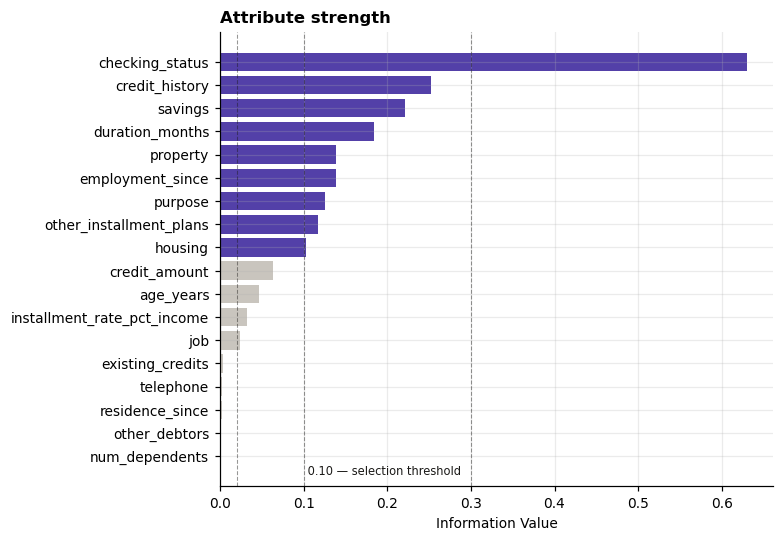

```
9 attributes carried forward: checking_status, credit_history, savings, duration_months, property, employment_since, purpose, other_installment_plans, housing
```

```python
fig, ax = plt.subplots(figsize=(7.2, 5))
d = iv.sort_values('IV')
ax.barh(d['attribute'], d['IV'], color=[ACC if v>=0.10 else '#c9c5be' for v in d['IV']])
for x in (0.02, 0.10, 0.30):
    ax.axvline(x, color=INK, lw=0.7, ls='--', alpha=0.45)
ax.text(0.10, -0.8, ' 0.10 — selection threshold', fontsize=7.5, color=INK)
ax.set_xlabel('Information Value'); ax.set_title('Attribute strength', loc='left', fontweight='bold')
plt.tight_layout(); plt.show()

SELECTED = iv.loc[iv['IV'] >= 0.10, 'attribute'].tolist()
print(f"{len(SELECTED)} attributes carried forward: {', '.join(SELECTED)}")
```

### Reading the strongest attribute

Information Value says which attributes matter. The WOE table says *what they say* — and this one is worth reading, because the most predictive attribute in the dataset behaves in a way that surprises people.

```
checking_status  (IV = 0.630)

bad                n  bad_rate    woe    iv
checking_status
< 0 DM           192     0.479 -0.759 0.176
0-200 DM         188     0.394 -0.412 0.049
>= 200 DM         44     0.273  0.114 0.001
no account       276     0.116  1.176 0.404
```

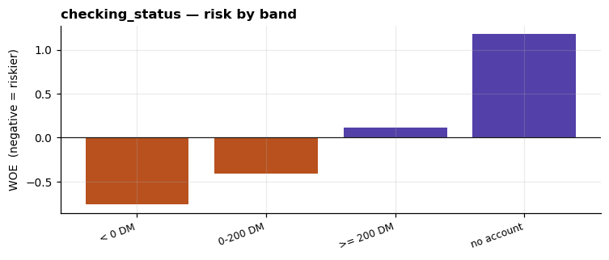

```python
top = iv.iloc[0]['attribute']
b, _ = make_bins(X_tr[top], y_tr)
t = woe_table(b, y_tr).sort_values('woe')
show = t[['n','bad_rate','woe','iv']].copy()
print(f"{top}  (IV = {t['iv'].sum():.3f})\n")
print(show.to_string(float_format=lambda v: f"{v:,.3f}"))

fig, ax = plt.subplots(figsize=(7, 3))
ax.bar(range(len(t)), t['woe'], color=[WARN if w<0 else ACC for w in t['woe']])
ax.set_xticks(range(len(t))); ax.set_xticklabels(t.index, rotation=20, ha='right', fontsize=8)
ax.axhline(0, color=INK, lw=0.8)
ax.set_ylabel('WOE  (negative = riskier)')
ax.set_title(f'{top} — risk by band', loc='left', fontweight='bold')
plt.tight_layout(); plt.show()
```

Applicants with **no checking account** are the *safest* group, not the riskiest — well ahead of those holding a positive balance. The intuitive reading, that a missing account means a thin file and therefore more risk, is backwards here.

The likely explanation is that in this population people who do not run a checking account at the lending bank are banking elsewhere and are not overdrawn where the bank can see it, whereas a visible balance below 0 DM is exactly what it looks like. Whatever the cause, it is a reminder to bin from the data rather than from intuition — an analyst who imposed a sensible-looking monotonic order on this attribute would have damaged the model.

## 4. Scorecard model — logistic regression on WOE

```python
def apply_woe(frame):
    out = pd.DataFrame(index=frame.index)
    for c in SELECTED:
        kind, spec = bin_spec[c]
        if kind == 'num':
            b = pd.cut(frame[c], bins=pd.IntervalIndex(spec)).astype(str)
        else:
            b = frame[c].where(frame[c].isin(spec), 'other').astype(str)
        # Unseen bin -> WOE 0, i.e. neutral rather than an arbitrary guess
        out[c] = b.map(woe_maps[c]).fillna(0.0).astype(float)
    return out

W_tr, W_te = apply_woe(X_tr), apply_woe(X_te)

logit = LogisticRegression(max_iter=2000, C=1.0, random_state=RS).fit(W_tr, y_tr)
p_tr, p_te = logit.predict_proba(W_tr)[:,1], logit.predict_proba(W_te)[:,1]

cv = cross_val_score(LogisticRegression(max_iter=2000, C=1.0, random_state=RS),
                     W_tr, y_tr, cv=StratifiedKFold(5, shuffle=True, random_state=RS),
                     scoring='roc_auc')
print(f"AUC  train {roc_auc_score(y_tr,p_tr):.3f}   5-fold CV {cv.mean():.3f} (+/- {cv.std():.3f})   test {roc_auc_score(y_te,p_te):.3f}")

coefs = (pd.DataFrame({'attribute': SELECTED, 'coefficient': logit.coef_[0]})
           .assign(abs_=lambda d: d['coefficient'].abs())
           .sort_values('abs_', ascending=False).drop(columns='abs_').reset_index(drop=True))
print("\nAll coefficients should be positive: higher WOE = safer = lower modelled risk.")
coefs
```

[output not shown]

|  | attribute | coefficient |
| --- | --- | --- |
| 0 | duration_months | -0.928329 |
| 1 | purpose | -0.814065 |
| 2 | savings | -0.798942 |
| 3 | checking_status | -0.776923 |
| 4 | employment_since | -0.739642 |
| 5 | other_installment_plans | -0.664000 |
| 6 | credit_history | -0.616969 |
| 7 | housing | -0.476822 |
| 8 | property | -0.389717 |

## 5. What does interpretability cost?

A scorecard is worth having only if the accuracy given up is small. Gradient boosting is the honest comparison — it sees the raw attributes with no binning and no monotonic constraint.

```python
Xg_tr = X_tr[SELECTED].copy(); Xg_te = X_te[SELECTED].copy()
for c in SELECTED:
    if not pd.api.types.is_numeric_dtype(Xg_tr[c]):
        cats = pd.Categorical(Xg_tr[c]).categories
        Xg_tr[c] = pd.Categorical(Xg_tr[c], categories=cats).codes
        Xg_te[c] = pd.Categorical(Xg_te[c], categories=cats).codes

gbm = HistGradientBoostingClassifier(max_depth=3, max_iter=250, learning_rate=0.06,
                                     l2_regularization=1.0, random_state=RS).fit(Xg_tr, y_tr)
p_gbm = gbm.predict_proba(Xg_te)[:,1]

auc_lr, auc_gb = roc_auc_score(y_te, p_te), roc_auc_score(y_te, p_gbm)
print(f"Scorecard (logistic on WOE)  test AUC {auc_lr:.3f}")
print(f"Gradient boosting            test AUC {auc_gb:.3f}")
print(f"\nDifference: {auc_gb-auc_lr:+.3f} AUC")
```

```
Scorecard (logistic on WOE)  test AUC 0.779
Gradient boosting            test AUC 0.758

Difference: -0.021 AUC
```

**The scorecard wins.** Not by much, but the direction is the point: binning into Weight of Evidence gave up nothing to a gradient booster with full access to the raw attributes.

That is not a general result, it is a consequence of this dataset. Seven hundred training rows is far too few for a tree ensemble to find real interactions, so most of what it learns past the main effects is noise, while WOE binning acts as heavy regularisation and throws that noise away. On a book of a hundred thousand applications the ordering would very likely reverse.

The useful conclusion is narrower and still worth having: **on a small book, the interpretable model is not a compromise.** The argument for a scorecard here is not "worth the accuracy trade-off" — there is no trade-off to make.

## 6. How a risk team reads the model

**KS** — the widest gap between the cumulative good and bad distributions. It answers "how well does the score pull the two populations apart", and it names the score where the separation is greatest.

**Gains** — if we decline the riskiest decile, what share of all bad loans do we avoid? This is the chart that decides whether a model is worth deploying.

**Calibration** — does a predicted 20% actually default 20% of the time? Ranking is enough for accept/decline, but pricing and provisioning need the level to be right too.

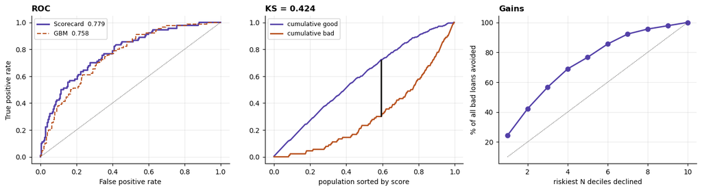

```
KS 0.424 at p = 0.304
Declining the riskiest 3 deciles avoids 57% of all bad loans.
Brier score 0.1660  (lower is better; 0.25 = uninformative)
```

```python
def ks_stat(y_true, p):
    o = np.argsort(p)
    yy = np.asarray(y_true)[o]
    cb = np.cumsum(yy) / max(yy.sum(), 1)
    cg = np.cumsum(1-yy) / max((1-yy).sum(), 1)
    i = np.argmax(cg - cb)
    return (cg - cb)[i], np.sort(p)[i], cg, cb

ks, ks_at, cg, cb = ks_stat(y_te, p_te)

fig, axes = plt.subplots(1, 3, figsize=(13, 3.6))

fpr, tpr, _ = roc_curve(y_te, p_te)
fg, tg, _   = roc_curve(y_te, p_gbm)
axes[0].plot(fpr, tpr, color=ACC, lw=2, label=f'Scorecard  {auc_lr:.3f}')
axes[0].plot(fg, tg, color=WARN, lw=1.4, ls='--', label=f'GBM  {auc_gb:.3f}')
axes[0].plot([0,1],[0,1], color=INK, lw=0.7, ls=':')
axes[0].set_xlabel('False positive rate'); axes[0].set_ylabel('True positive rate')
axes[0].set_title('ROC', loc='left', fontweight='bold'); axes[0].legend(fontsize=8)

xs = np.arange(len(cg))/len(cg)
axes[1].plot(xs, cg, color=ACC, lw=1.8, label='cumulative good')
axes[1].plot(xs, cb, color=WARN, lw=1.8, label='cumulative bad')
j = np.argmax(cg-cb)
axes[1].vlines(xs[j], cb[j], cg[j], color=INK, lw=2)
axes[1].set_title(f'KS = {ks:.3f}', loc='left', fontweight='bold')
axes[1].set_xlabel('population sorted by score'); axes[1].legend(fontsize=8)

dec = pd.DataFrame({'p': p_te, 'bad': y_te.values})
dec['decile'] = pd.qcut(dec['p'].rank(method='first'), 10, labels=False)
g = dec.groupby('decile')['bad'].sum().iloc[::-1].cumsum() / dec['bad'].sum()
axes[2].plot(range(1,11), g.values*100, marker='o', color=ACC, lw=1.8)
axes[2].plot([1,10],[10,100], color=INK, lw=0.7, ls=':')
axes[2].set_xlabel('riskiest N deciles declined'); axes[2].set_ylabel('% of all bad loans avoided')
axes[2].set_title('Gains', loc='left', fontweight='bold')
plt.tight_layout(); plt.show()

print(f"KS {ks:.3f} at p = {ks_at:.3f}")
print(f"Declining the riskiest 3 deciles avoids {g.values[2]*100:.0f}% of all bad loans.")
print(f"Brier score {brier_score_loss(y_te, p_te):.4f}  (lower is better; 0.25 = uninformative)")
```

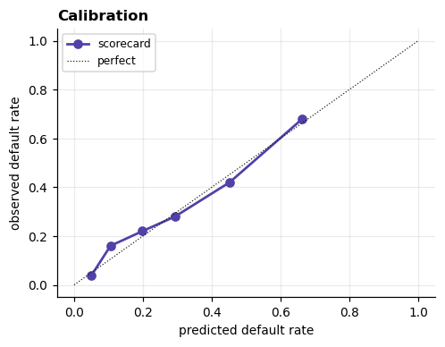

```python
fig, ax = plt.subplots(figsize=(4.6, 3.6))
pt, pp = calibration_curve(y_te, p_te, n_bins=6, strategy='quantile')
ax.plot(pp, pt, marker='o', color=ACC, lw=1.8, label='scorecard')
ax.plot([0,1],[0,1], color=INK, lw=0.8, ls=':', label='perfect')
ax.set_xlabel('predicted default rate'); ax.set_ylabel('observed default rate')
ax.set_title('Calibration', loc='left', fontweight='bold'); ax.legend(fontsize=8)
plt.tight_layout(); plt.show()
```

## 7. The scorecard

Converting the model into points. The standard scaling fixes two anchors — a reference score at reference odds, and the number of points that doubles the odds (PDO):

$$\text{factor} = \frac{PDO}{\ln 2}, \qquad \text{offset} = \text{score}_0 - \text{factor}\times\ln(\text{odds}_0)$$

$$\text{points}_{ij} = -\left(\beta_i \times WOE_{ij} + \frac{\alpha}{n}\right)\times \text{factor} + \frac{\text{offset}}{n}$$

Here: 600 points at 50:1 good:bad odds, 20 points to double. This is the deliverable — an underwriter reads an applicant's attributes off the table, adds up the points, and compares the total to the cut-off. No model needs to be running for a decision to be explained.

```python
PDO, SCORE0, ODDS0 = 20, 600, 50
factor = PDO/np.log(2); offset = SCORE0 - factor*np.log(ODDS0)
n = len(SELECTED); alpha = logit.intercept_[0]

rows = []
for i, c in enumerate(SELECTED):
    beta = logit.coef_[0][i]
    b, _ = make_bins(X_tr[c], y_tr)
    tab = woe_table(b, y_tr)
    for lvl, r in tab.iterrows():
        rows.append({'attribute': c, 'band': lvl, 'n': int(r['n']),
                     'bad_rate': r['bad_rate'], 'woe': r['woe'],
                     'points': -(beta*r['woe'] + alpha/n)*factor + offset/n})

card = pd.DataFrame(rows)
card['points'] = card['points'].round().astype(int)
card = card.sort_values(['attribute','points'])
print(f"Scorecard: {card['attribute'].nunique()} attributes, {len(card)} bands")
print(f"Score range {card.groupby('attribute')['points'].min().sum()} – {card.groupby('attribute')['points'].max().sum()}\n")
card.to_csv('scorecard.csv', index=False)
card.style.format({'bad_rate':'{:.1%}','woe':'{:+.3f}'}).hide(axis='index').bar(
    subset=['points'], color='#cfc6f0')
```

```
Scorecard: 9 attributes, 41 bands
Score range 387 – 620
```

| attribute | band | n | bad_rate | woe | points |
| --- | --- | --- | --- | --- | --- |
| checking_status | < 0 DM | 192 | 47.9% | -0.759 | 40 |
| checking_status | 0-200 DM | 188 | 39.4% | -0.412 | 48 |
| checking_status | >= 200 DM | 44 | 27.3% | +0.114 | 59 |
| checking_status | no account | 276 | 11.6% | +1.176 | 83 |
| credit_history | other | 28 | 57.1% | -1.118 | 37 |
| credit_history | all paid (this bank) | 38 | 55.3% | -1.046 | 38 |
| credit_history | past delay | 67 | 32.8% | -0.136 | 54 |
| credit_history | paid to date | 362 | 31.8% | -0.078 | 55 |
| credit_history | critical / other bank | 205 | 17.6% | +0.695 | 69 |
| duration_months | (30.0, 60.0] | 121 | 44.6% | -0.627 | 40 |
| duration_months | (15.0, 24.0] | 230 | 34.3% | -0.196 | 52 |
| duration_months | (24.0, 30.0] | 40 | 32.5% | -0.129 | 53 |
| duration_months | (12.0, 15.0] | 49 | 20.4% | +0.484 | 70 |
| duration_months | (3.999, 12.0] | 260 | 20.8% | +0.492 | 70 |
| employment_since | unemployed | 37 | 45.9% | -0.682 | 42 |
| employment_since | < 1 yr | 120 | 43.3% | -0.575 | 45 |
| employment_since | 1-4 yrs | 246 | 28.5% | +0.077 | 58 |
| employment_since | >= 7 yrs | 184 | 26.1% | +0.194 | 61 |
| employment_since | 4-7 yrs | 113 | 20.4% | +0.508 | 68 |
| housing | free | 75 | 41.3% | -0.498 | 50 |
| housing | rent | 123 | 40.7% | -0.468 | 50 |
| housing | own | 502 | 25.7% | +0.216 | 60 |
| other_installment_plans | bank | 99 | 47.5% | -0.743 | 43 |
| other_installment_plans | stores | 38 | 36.8% | -0.319 | 51 |
| other_installment_plans | none | 563 | 26.5% | +0.177 | 60 |
| property | none | 111 | 45.9% | -0.681 | 49 |
| property | car / other | 231 | 30.7% | -0.033 | 56 |
| property | savings agreement | 159 | 28.9% | +0.050 | 57 |
| property | real estate | 199 | 21.1% | +0.468 | 62 |
| purpose | education | 35 | 51.4% | -0.893 | 36 |
| purpose | business | 69 | 34.8% | -0.219 | 52 |
| purpose | new car | 171 | 33.9% | -0.175 | 53 |
| purpose | furniture | 126 | 32.5% | -0.115 | 54 |
| purpose | other | 37 | 32.4% | -0.125 | 54 |
| purpose | radio/TV | 186 | 22.6% | +0.386 | 66 |
| purpose | used car | 76 | 19.7% | +0.540 | 70 |
| savings | < 100 DM | 417 | 36.7% | -0.296 | 50 |
| savings | 100-500 DM | 81 | 32.1% | -0.101 | 55 |
| savings | 500-1000 DM | 41 | 17.1% | +0.686 | 73 |
| savings | unknown / none | 124 | 15.3% | +0.848 | 76 |
| savings | >= 1000 DM | 37 | 13.5% | +0.936 | 78 |

## 8. Where to set the cut-off

The decision the whole exercise exists to support — and the step most analyses skip by defaulting to a 0.5 threshold.

0.5 is only correct when the two errors cost the same. Here the data documentation says they do not: **approving a bad applicant costs 5, declining a good one costs 1.** The optimal threshold follows from that ratio, not from convention.

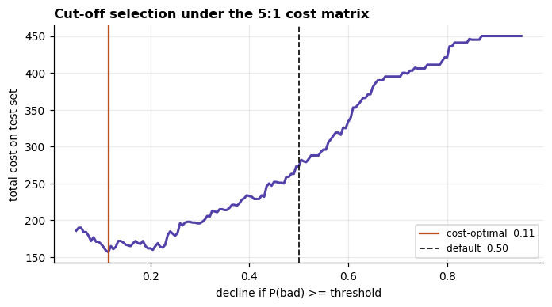

```
              threshold  declined  bad caught  bad approved  good declined  good approved  bad capture  cost
default 0.50      0.500        63          40            50             23            187        0.444   273
cost-optimal      0.115       217          85             5            132             78        0.944   157

Moving the cut-off from 0.50 to 0.11 cuts cost by 116 units (42%) on the same model.
```

```python
C_FN, C_FP = 5, 1     # documented with the dataset
ths = np.linspace(0.05, 0.95, 181)
cost = [( ((p_te>=t)&(y_te==0)).sum()*C_FP + ((p_te<t)&(y_te==1)).sum()*C_FN ) for t in ths]
best = ths[int(np.argmin(cost))]
naive = 0.5

fig, ax = plt.subplots(figsize=(6.4, 3.6))
ax.plot(ths, cost, color=ACC, lw=2)
ax.axvline(best, color=WARN, lw=1.5, label=f'cost-optimal  {best:.2f}')
ax.axvline(naive, color=INK, lw=1.2, ls='--', label='default  0.50')
ax.set_xlabel('decline if P(bad) >= threshold'); ax.set_ylabel('total cost on test set')
ax.set_title('Cut-off selection under the 5:1 cost matrix', loc='left', fontweight='bold')
ax.legend(fontsize=8); plt.tight_layout(); plt.show()

def report(t):
    dec = p_te >= t
    tp = int(((dec)&(y_te==1)).sum()); fp = int(((dec)&(y_te==0)).sum())
    fn = int(((~dec)&(y_te==1)).sum()); tn = int(((~dec)&(y_te==0)).sum())
    return {'threshold':t, 'declined':int(dec.sum()), 'bad caught':tp, 'bad approved':fn,
            'good declined':fp, 'good approved':tn,
            'bad capture':tp/max(tp+fn,1), 'cost':tp*0+fp*C_FP+fn*C_FN}

cmp = pd.DataFrame([report(naive), report(best)], index=['default 0.50','cost-optimal'])
print(cmp.to_string(float_format=lambda v: f"{v:,.3f}"))
saved = cmp.loc['default 0.50','cost'] - cmp.loc['cost-optimal','cost']
print(f"\nMoving the cut-off from 0.50 to {best:.2f} cuts cost by {saved:.0f} units "
      f"({saved/cmp.loc['default 0.50','cost']:.0%}) on the same model.")
```

### The cut-off this produces is not one a lender would ship

Taken literally, the cost-optimal threshold declines roughly seven applicants in ten. No lending business survives that, and it is worth being clear about why the number comes out that way.

The cost function only counts the cost of *errors*. It has no term for the money a good loan earns. Given only a 5:1 penalty and no revenue on the other side of the ledger, the cheapest possible book is one that lends to almost nobody — the optimiser is answering the question it was asked, and the question was incomplete.

A production version prices both sides: expected profit per approved good loan against expected loss given default per approved bad one, which pulls the threshold back up to something the business can run. The 5:1 matrix is still the right correction to the naive 0.5 default, and it is still the step most analyses skip. It is just not the whole objective.

## What this shows

The cut-off is worth as much as the model. Same predictions, same AUC — moving the threshold to reflect what the errors actually cost removes a material share of the loss, and no amount of additional feature engineering would have found it.

**Honest limits.** A thousand applications is a small book, so the test set is 300 rows and the confidence interval around that AUC is wide. The data is from 1990s Germany and the economics do not transfer. There is no out-of-time sample, so nothing here speaks to stability — in production the first thing to build is a Population Stability Index against the development sample, because scorecards fail by drifting, not by being wrong on day one.

**What I would add next:** reject inference, since the book only contains applicants who were approved and the model never sees the ones that were turned away; and a monotonic constraint on age and duration so the bins cannot invert on a small sample.